# Set de Ejercicios 4

Daniel Juárez Bautista

22 de abril de 2020

# Detalles

- Con quién trabajaste:
- Aproximadamente cuánto tiempo trabajaste en este set de ejercicios: Tres horas
- Qué te dio más trabajo: El gráfico de pendiente porque los datos eran demasiados y el proceso de reducir las observaciones requirió valorar qué quería mostrar pues si incluía todos los datos, el gráfico se saturaba y no se podía interpretar nada.

Para esta tarea tienes pocas instrucciones. Utilizarás datos de uso de agua en ciertos períodos de tiempo y de desempleo en estados de los Estados Unidos para varios años. Carga las bases de datos y realiza los gráficos a continuación. Pista: Es posible que tengas que agrupar datos.

# Organiza los datos

```r
library(tidyverse)

water_usage <- read_csv("water_usage.csv")
unemployment <- read_csv("unemployment.csv")
```

# Parte 1: Gráficos Bala

Aquí observo el cambio en consumo de agua. En el gráfico, también se puede observar si estos consumos corresponden a niveles conservadores, altos o muy altos de consumo de agua.

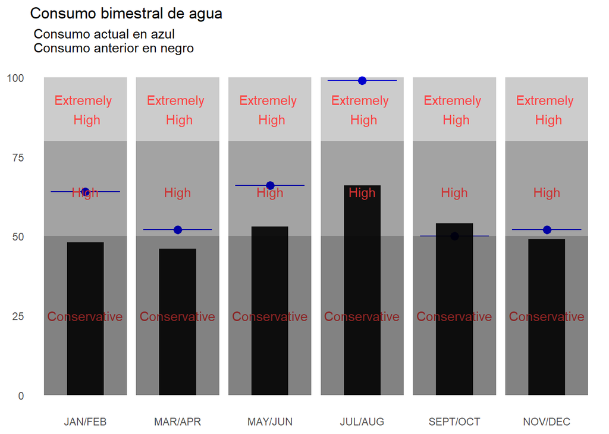

```r
water_usage$period <- factor(water_usage$period, levels = c("JAN/FEB", "MAR/APR", "MAY/JUN", "JUL/AUG", "SEPT/OCT", "NOV/DEC"))

ggplot(water_usage, aes(x = period)) +
   scale_y_continuous(labels = scales::comma) +
   geom_errorbar(aes(ymin = current, ymax = current), color = "blue", width = 0.75) +
  geom_point(aes(y = current), size = 3, color = "blue") +
  geom_col(aes(y = conservative), fill = "black", alpha = 0.2) +
  geom_col(aes(y = high), fill = "black", alpha = 0.2) +
  geom_col(aes(y = extremely_high), fill = "black", alpha = 0.2) +
  geom_col(aes(y = previous), fill = "black", width = 0.4, alpha = 0.9) +
  labs(x = NULL, y = NULL,
       title = "Consumo bimestral de agua",
       subtitle = " Consumo actual en azul \n Consumo anterior en negro") +
  geom_text(aes( y = conservative), label = "Conservative",position = position_stack(vjust=.5), colour="brown4") +
  geom_text(aes( y = high), label = "High",position = position_stack(vjust=.8), colour="brown3") +
  geom_text(aes( y = extremely_high), label = "Extremely \n High",position = position_stack(vjust=.9), colour="brown1") +
  theme_minimal() +
  theme(panel.grid.minor = element_blank(),
        panel.grid.major = element_blank())
```

# Parte 2: Múltiples pequeños

```r
library(ggridges)
library(scales)
unemployment$yearcat[unemployment$year < 2010] <- "2006-2009"
```

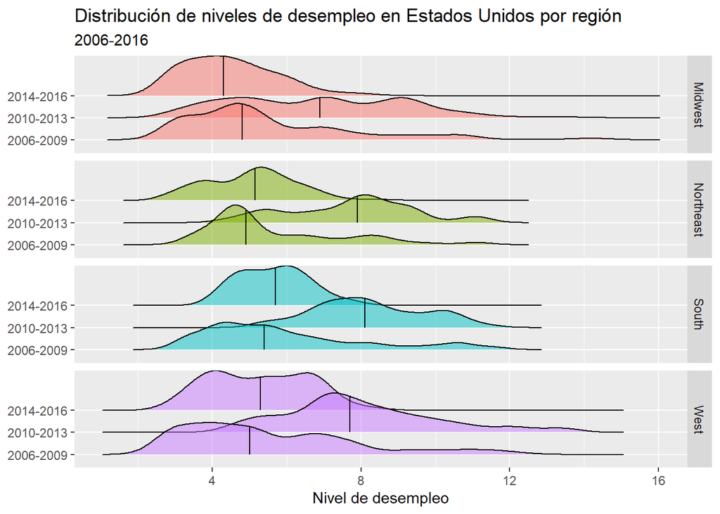

```r
unemployment$yearcat[unemployment$year<2014 & unemployment$year>2009] <- "2010-2013"
unemployment$yearcat[unemployment$year > 2013] <- "2014-2016"

ggplot(unemployment, aes(x = unemployment, y = as.factor(yearcat), fill = region)) +
         geom_density_ridges(quantile_lines = TRUE, quantiles = 2, alpha = 0.5) +
  labs(x = "Nivel de desempleo", y=NULL, title = "Distribución de niveles de desempleo en Estados Unidos por región", subtitle = "2006-2016")+
  facet_grid(region ~ .) +
  guides(fill = FALSE)
```

# Parte 3: Gráficos de Pendiente

Para esta gráfica, considero que los datos nos permiten observar cómo se recuperaron (si lo hicieron) algunos estados después de la crisis de 2008. Podemos observar que aumenta el nivel de desempleo para todos los estados pero la respuesta de recuperación es distinta para algunos. Me enfoco en la división pacífico por simplicidad y para no saturar la gráfica de datos.

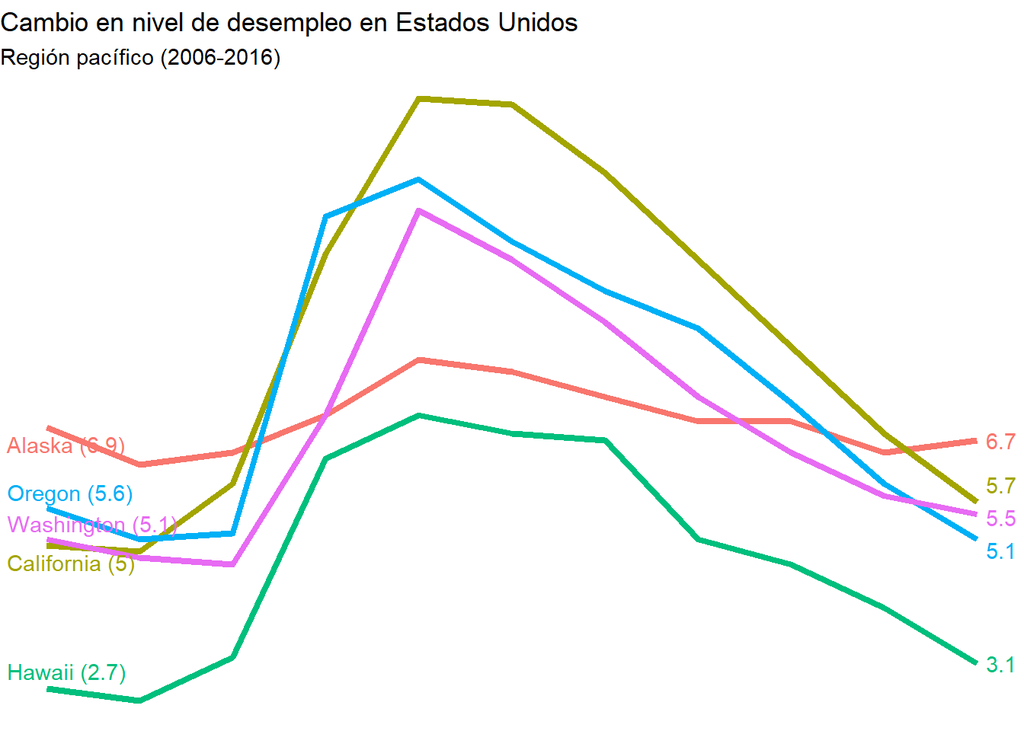

```r
library(ggrepel)
unemployment_first_last_pacific <- unemployment %>%
  filter(month==1) %>%
  filter(division == "Pacific") %>%
  mutate(label_first = ifelse(year == 2006, paste0(state, " (", unemployment, ")" ), NA),
         label_last = ifelse(year == 2016, unemployment, NA))

ggplot(unemployment_first_last_pacific, aes(x = year, y = unemployment, group = state, color = state)) +
  geom_line(size = 1.5) +
  geom_text_repel(aes(label = label_first), direction = "y", nudge_x = -1, seed = 1234) +
  geom_text_repel(aes(label = label_last), direction = "y", nudge_x = 1, seed = 1234) +
  guides(color = FALSE) +
  labs(title = "Cambio en nivel de desempleo en Estados Unidos", subtitle = "Región pacífico (2006-2016)") +
  theme_void()
```

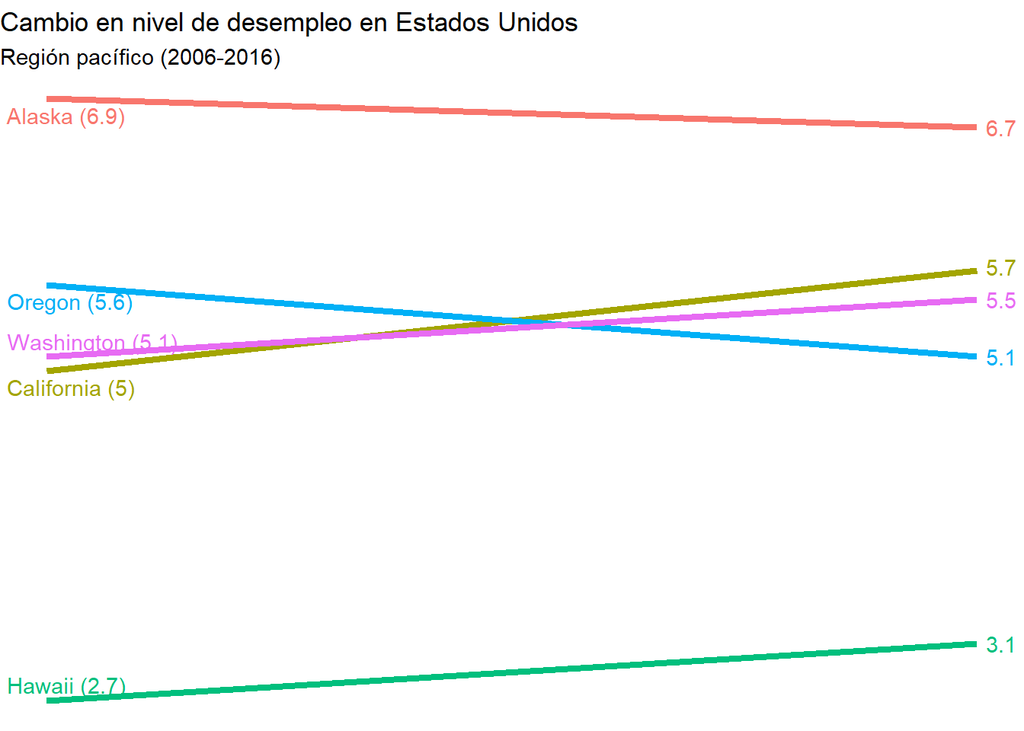

```r
unempl_f_l_pacific <-  unemployment_first_last_pacific %>%
  filter(year==2006 | year==2016)

  ggplot(unempl_f_l_pacific, aes(x = year, y = unemployment, group = state, color = state)) +
  geom_line(size = 1.5) +
  geom_text_repel(aes(label = label_first), direction = "y", nudge_x = -1, seed = 1234) +
  geom_text_repel(aes(label = label_last), direction = "y", nudge_x = 1, seed = 1234) +
  guides(color = FALSE) +
  labs(title = "Cambio en nivel de desempleo en Estados Unidos", subtitle = "Región pacífico (2006-2016)") +
  theme_void()
```